# TSM Assignment 1

Author

Jack Higgins

## Question (a) - Inspecting the mystery series

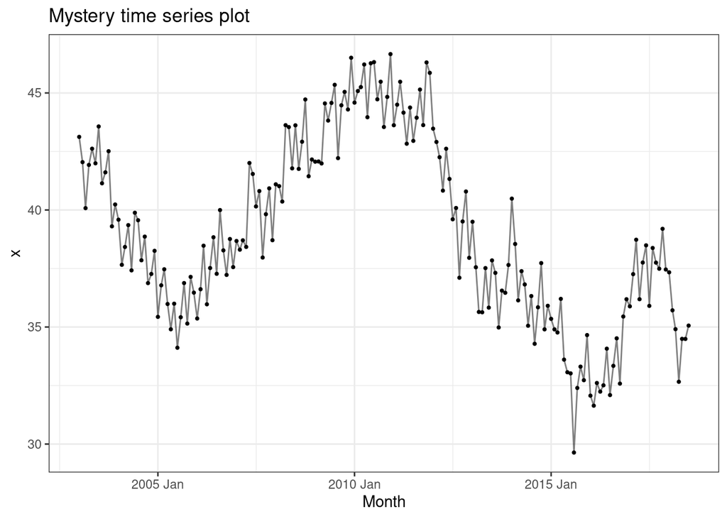

Figure 1: Mystery time series plot

**Summary:**

- The mystery series is plotted in Figure 1 above.
- The series exhibits a pattern of successive **increasing and decreasing trends**.
- We consider the series **non-stationary**, since the aforementioned trends cause the level of the series to vary over time. As a result, the series **requires differencing** before applying an ARIMA model.
- Although the appears to have a sinusoidal shape, we **cannot determine** if the series is **cyclic** as we don’t have enough observations.
- The series **does not appear to exhibit seasonality**. Although there may appear a pattern of troughs and peaks that may look seasonal at first glance, it seems that these don’t occur at regular intervals, and are likely better explained as a result of unusual effects.
- Variability does not seem to correlate with the level of the series, though there does seem to be an **increase in variability** in the series from September 2011 onwards.

**Further explanations:**

*Trends and cycles*

- The series appears to take on a sinusoidal shape, where there seems to be a pattern of roughly five years on an increasing trend followed by five years of a decreasing trend. Specifically, we see a decreasing trend from the start of the series until mid 2005, from which we see the start of about five years of an increasing trend, followed by another five years of decreasing, and so on.
- Although the shape of this series may look cyclic, given that we only have fifteen years of data for what might be a cycle with a period of ten years or more (or an irregular period), we don’t have enough information to conclude if the series is cyclic.

*Stationarity and differencing*

- The trends described above change the level of the series over time. This means the statistical properties will depend on the time at which the series is observed, and so by the definition given by Hyndman and Athanasopoulos in [Forecasting: Principles and Practice](https://otexts.com/fpp3/stationarity.html#fn15), the mystery series is non-stationary.
- As ARIMA models are only applicable to stationary series, we’ll need to transform the series to become stationary for part (b). We will see that taking the first difference yields a stationary series.

*Seasonality*

- There doesn’t appear to be any obvious signs of seasonality. Although there is a rough pattern of relative peaks followed by troughs, the frequency of such doesn’t appear to be consistent over time, leading us to conclude that it not likely to be a seasonal effect.
- We can see these patterns don’t appear to happen at regular intervals in Figure 2 below. This plot is similar to the regular time series plot above, except the x-axis shows data from within each season, which should make it easier to spot any seasonality. Although this plot does again show the behaviour of peaks being followed by troughs, it doesn’t appear that they occur in the same months each year, suggesting the behaviour is not seasonal. The periodogram provides further evidence that unusual effects have a significant impact on this series, as covered in question (d).

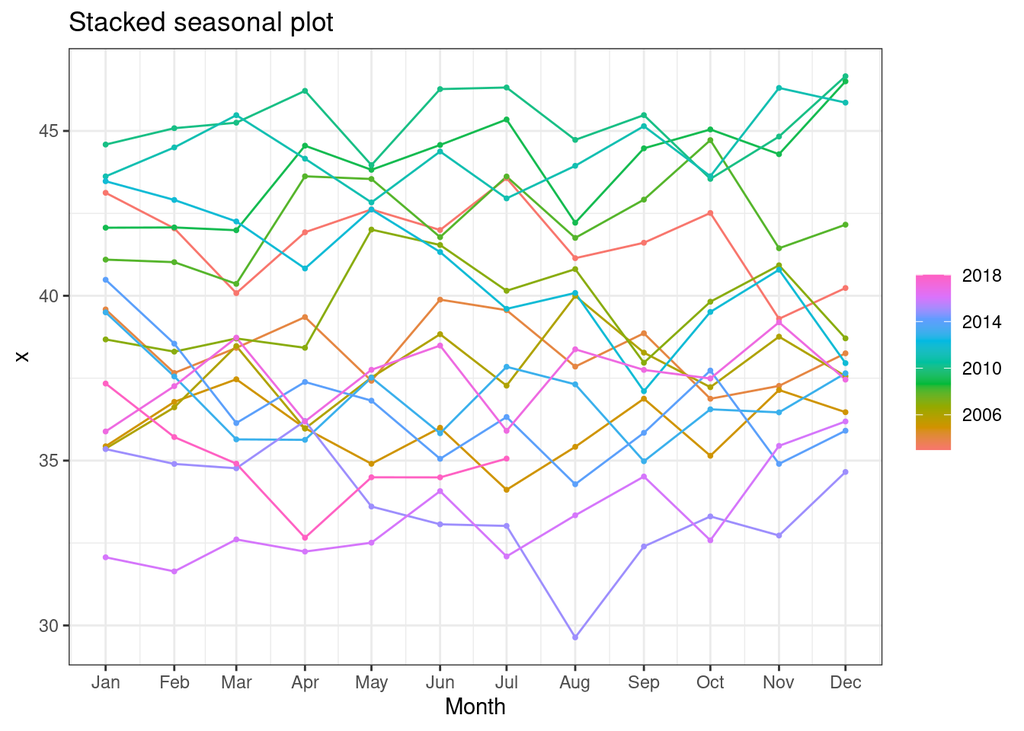

Figure 2: Seasonal stacked plot

*Variability*

- The variability of the series does not appear to change based on the level of the series.
- However, there seems to be a slight increase in variability after around September 2011, in the highlighted region of Figure 3 below. Since this change is quite small, for the sake of keeping our models and analysis simple we won’t make any adjustments for this.

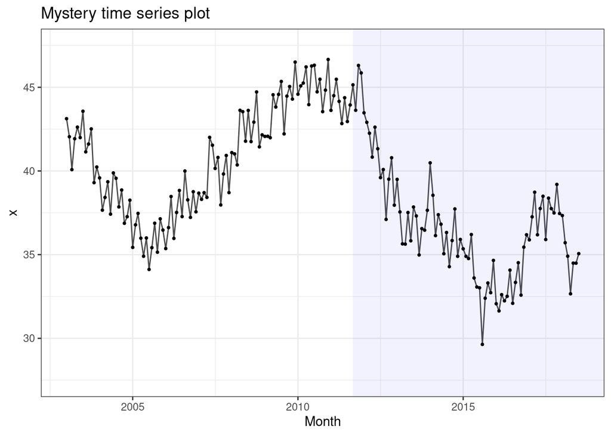

Figure 3: Variability change seen in the time series

## Question (b) - Fitting an ARIMA model

### Summary:

An `ARIMA(3,1,2)` model was chosen. The model outputs are printed below.

```r
unknown.ts.fit <- unknown.ts |>
  fabletools::model(fable::ARIMA(x ~ 0 + pdq(3,1,2) + PDQ(0,0,0)))

unknown.ts.fit |> fabletools::report()
```

```
Series: x
Model: ARIMA(3,1,2)

Coefficients:
          ar1      ar2      ar3     ma1     ma2
      -1.3710  -1.2472  -0.2141  1.1279  1.0000
s.e.   0.0779   0.0903   0.0777  0.0288  0.0213

sigma^2 estimated as 1.16:  log likelihood=-279.77
AIC=571.54   AICc=572.01   BIC=590.89
```

```r
cat("\nCoefficient t-statistics:\n")
```

```
Coefficient t-statistics:
```

```r
unknown.ts.fit[[1]][[1]]$fit$par$statistic
```

```
       ar1        ar2        ar3        ma1        ma2
-17.588837 -13.812721  -2.755308  39.147836  46.975072
```

### Model selection

#### Model identification

- Before fitting an ARIMA model, we must first ensure our data is stationary. Our series does not have seasonality, not does the variability appear to change with the level. Thus, the only transformation we need to perform is differencing to remove the trend component.
- As discussed in [Forecasting: Principles and Practice](https://otexts.com/fpp3/stationarity.html), a series of successive *Kwiatkowski-Phillips-Schmidt-Shin (KPSS) tests* ([Kwiatkowski et al., 1992](https://otexts.com/fpp3/stationarity.html#ref-KPSS92)) can be used to determine the number of rounds of first differencing required. This is applied in the code block below, suggesting that a single difference is sufficient to make the data stationary.

  ```r
  unknown.ts |>
    fabletools::features(x, unitroot_ndiffs) |>
    dplyr::pull() |>
    base::cat()
  ```

  ```
  1
  ```

- When we plot the resultant series in Figure 4, we note that it appears to now be stationary.

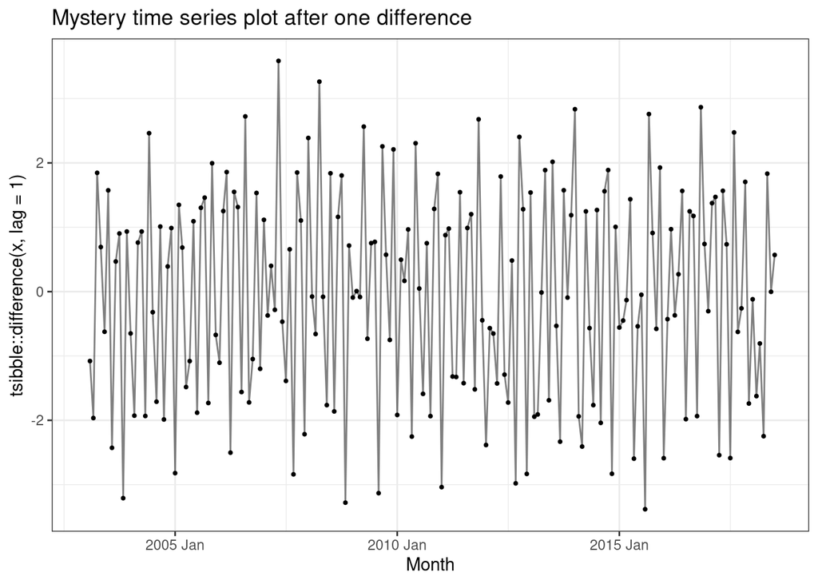

  Figure 4: Mystery time series plot after one difference

- Although we could have jumped straight to visualising the plots to determine the amount of differencing required, it’s nice to have multiple methods that all agree with each other.
- Thus, in our ARIMA model, we set `d = 1`.
- To start exploring what we might choose for `p` and `q`, we plot the ACF and PACF in Figure 5.

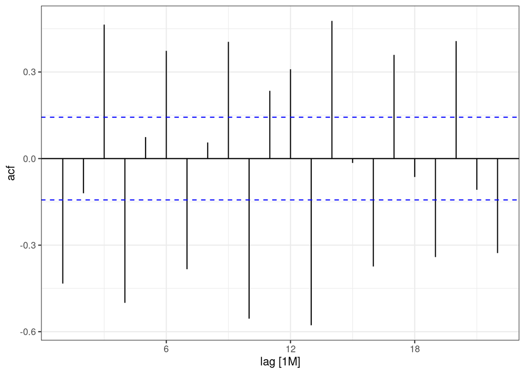

(a) ACF

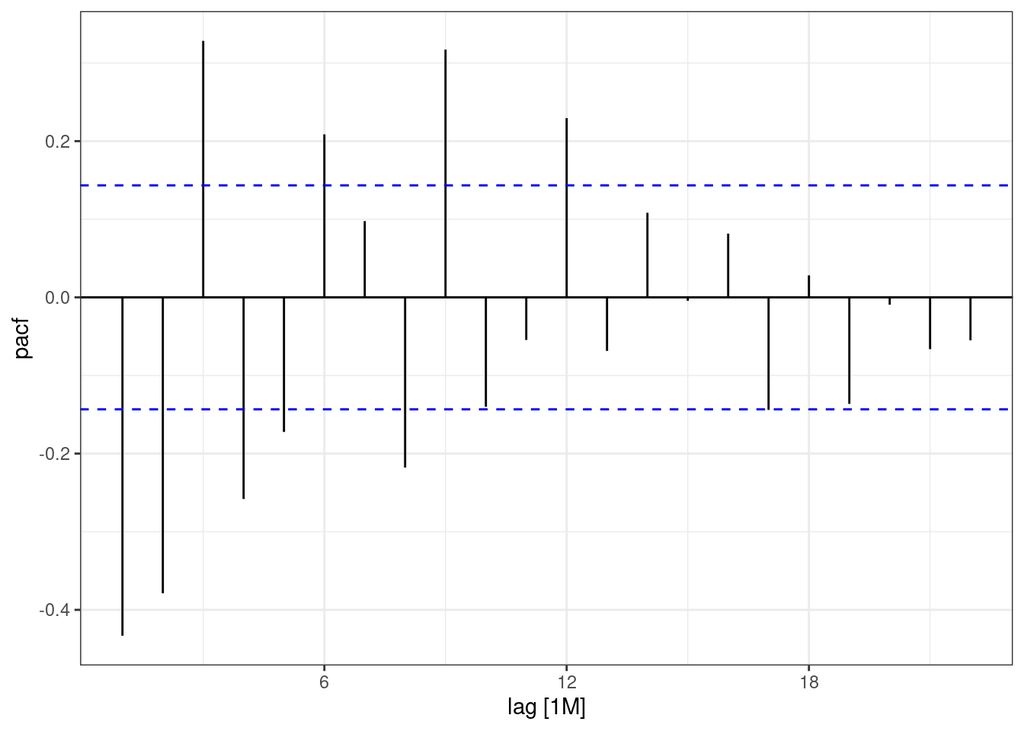

(b) PACF

Figure 5: Mystery differenced time series correlation plots

- Note that these plots show many significant peaks over an extended time period, so the usual methods of using these plots to give us starting values for `p` and `q` isn’t so useful here, though it does reveal that there may be both autoregressive and moving average components.
- However, note that each plot seems to have a pattern that repeats roughly every three peaks. This may indicate that each month in the series is significantly correlated with the value three months ago, so it might make sense to start by investigating a model with `p = q = 3`.
- We attempt to fit this model using R below, but instead receive a warning with no fit provided:

```r
unknown.ts |>
  fabletools::model(fable::ARIMA(x ~ 0 + pdq(3,1,3) + PDQ(0,0,0))) |>
  fabletools::report()
```

```
Warning: 1 error encountered for fable::ARIMA(x ~ 0 + pdq(3, 1, 3) + PDQ(0, 0, 0))
[1] non-stationary AR part from CSS
```

```
Series: x
Model: NULL model
NULL model
```

- This warning is received because the autoregressive coefficients estimated are non-stationary, as described by [Rob Hyndman here](https://stackoverflow.com/a/7236919). Specifically, there is [at least one root of the AR polynomial that lies outside the unit circle](https://otexts.com/fpp3/arima-r.html#plotting-the-characteristic-roots).
- As mentioned in the TSM lecture notes (pg. 52), this ensures the model selected will be invertible and causal, both of which are desirable. As covered in the lecture notes (pg. 54), if we wish to produce forecast intervals using a model, we require that the model has both these properties.
- Thus, a `(3, 1, 3)` model is not appropriate.

#### Model search

```r
models <- base::expand.grid(p = 0:5, q = 0:5)

results <- tibble::tibble()

for (i in 1:nrow(models)) {
  p <- models[i, "p"]
  q <- models[i, "q"]

  try({
    model_results <-
      unknown.ts |>
      fabletools::model(fable::ARIMA(x ~ 0 + pdq(p, 1, q) + PDQ(0, 0, 0))) |>
      fabletools::glance()
  })
  if (nrow(model_results) > 0) { # Only include non-empty results
    model_results <-
      model_results |>
      dplyr::mutate(model = "ARIMA", p = p, d = 1, q = q, .before = sigma2) |>
      dplyr::mutate(dplyr::across(where(is.numeric), round, 3)) |>
      dplyr::select(-.model, -ar_roots, -ma_roots)

    results <- dplyr::bind_rows(results, model_results)
  }
}

results <- results |> dplyr::arrange(AIC, p, q)

knitr::kable(head(results, 13))
```

Table 1: $ARIMA(p,d,q)$ model outputs

| model | p | d | q | sigma2 | log_lik | AIC | AICc | BIC |
| --- | --- | --- | --- | --- | --- | --- | --- | --- |
| ARIMA | 2 | 1 | 5 | 1.117 | -275.685 | 567.371 | 568.184 | 593.177 |
| ARIMA | 3 | 1 | 5 | 1.123 | -275.619 | 569.239 | 570.261 | 598.270 |
| ARIMA | 3 | 1 | 2 | 1.160 | -279.769 | 571.537 | 572.007 | 590.892 |
| ARIMA | 2 | 1 | 3 | 1.164 | -280.097 | 572.195 | 572.664 | 591.549 |
| ARIMA | 5 | 1 | 3 | 1.145 | -277.379 | 572.758 | 573.781 | 601.790 |
| ARIMA | 5 | 1 | 2 | 1.152 | -278.469 | 572.938 | 573.751 | 598.744 |
| ARIMA | 4 | 1 | 2 | 1.162 | -279.487 | 572.973 | 573.602 | 595.553 |
| ARIMA | 2 | 1 | 4 | 1.169 | -280.007 | 574.014 | 574.643 | 596.595 |
| ARIMA | 4 | 1 | 3 | 1.173 | -279.763 | 575.526 | 576.340 | 601.332 |
| ARIMA | 3 | 1 | 4 | 1.168 | -279.813 | 575.626 | 576.439 | 601.432 |
| ARIMA | 2 | 1 | 2 | 1.200 | -283.625 | 577.251 | 577.584 | 593.379 |
| ARIMA | 4 | 1 | 4 | 1.156 | -279.998 | 577.995 | 579.018 | 607.027 |
| ARIMA | 5 | 1 | 1 | 1.543 | -301.876 | 617.751 | 618.381 | 640.332 |

```r
unknown.ts |>
  fabletools::model(fable::ARIMA(x ~ 0 + pdq(2,1,2) + PDQ(0,0,0))) |>
  fabletools::report()
```

```
Series: x
Model: ARIMA(2,1,2)

Coefficients:
          ar1      ar2     ma1    ma2
      -1.1569  -0.9986  1.1086  1.000
s.e.   0.0033   0.0016  0.0226  0.026

sigma^2 estimated as 1.2:  log likelihood=-283.63
AIC=577.25   AICc=577.58   BIC=593.38
```

```r
unknown.ts |>
  fabletools::model(fable::ARIMA(x ~ 0 + pdq(3,1,2) + PDQ(0,0,0))) |>
  fabletools::report()
```

```
Series: x
Model: ARIMA(3,1,2)

Coefficients:
          ar1      ar2      ar3     ma1     ma2
      -1.3710  -1.2472  -0.2141  1.1279  1.0000
s.e.   0.0779   0.0903   0.0777  0.0288  0.0213

sigma^2 estimated as 1.16:  log likelihood=-279.77
AIC=571.54   AICc=572.01   BIC=590.89
```

## Question (c) - Residual analysis

### Summary

- Although the simplest model has been chosen the residual component from the model may appear to be white noise, it appears that the residual terms are auto-correlated, not independent.
- This suggests the selected ARIMA model is not an appropriate model, as only two of the required three properties are observed.
- This is not unexpected, as alluded to earlier, we suspect there are unusual effects in the data that may result in autocorrelation.

### Exploring the residuals

- In order to come to the conclusions above, the residual time series and residual series ACF were plotted in Figure 6 below.

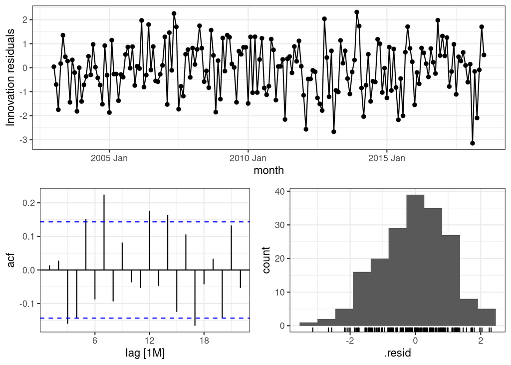

Figure 6: Plots of the residual series

```r
feasts::gg_tsresiduals(unknown.ts.fit) # plot residuals and ACF
```

```r
n <- nrow(unknown.ts)
num_turning_points_upper <- (2 * n / 3) + 1.96 * sqrt(8 * n / 45)
num_turning_points_lower <- (2 * n / 3) - 1.96 * sqrt(8 * n / 45)

num_turning_points <- 0
model_residuals <- stats::residuals(unknown.ts.fit)
for (row in 2:(nrow(model_residuals) - 1)) {
  prev_x <- model_residuals[[ row - 1, ".resid"]]
  curr_x <- model_residuals[[ row, ".resid"]]
  next_x <- model_residuals[[ row + 1, ".resid"]]

  if ((prev_x < curr_x & curr_x > next_x) |
      (prev_x > curr_x & curr_x < next_x)) {
    num_turning_points <- num_turning_points + 1
  }
}

residuals_mean <- base::mean(model_residuals$.resid)

cat(paste("Residual series mean:", round(residuals_mean, 4)))
```

```
Residual series mean: -0.0503
```

```r
cat(paste0("\nNumber of turning points: ", num_turning_points,
          ", Upper bound: ", round(num_turning_points_upper),
          ", Lower bound: ", round(num_turning_points_lower)))
```

```
Number of turning points: 128, Upper bound: 136, Lower bound: 113
```

## Question (d) - Spectral analysis

- A variety of spectral estimations are plotted in Figure 7 below.

```r
# Note: We use ggplot to plot in this cell, instead of the built in plot options
# Get differenced series
unknown_diff <- difference(unknown.ts$x, lag = 1)
unknown_diff <- unknown_diff[!is.na(unknown_diff)]

# Raw periodograms
# Detrend doesn't make sense to use as it removes a linear trend,
# but our series doesn't have a linear trend.
periodogram_raw <-
  stats::spec.pgram(unknown.ts$x, detrend = FALSE, log = "no", plot = FALSE)

periodogram_diff <-
  stats::spec.pgram(unknown_diff, detrend = FALSE, log = "no", plot = FALSE)

# Smoothed
smoothed_periodogram_raw <- stats::spec.pgram(
  unknown.ts$x,
  detrend = FALSE,
  log = "no",
  kernel("daniell", 1),
  plot = FALSE
)
smoothed_periodogram_diff <- stats::spec.pgram(
  unknown_diff,
  detrend = FALSE,
  log = "no",
  kernel("daniell", 1),
  plot = FALSE
)

# AR spectral approximation
ar_spec_raw <-
  stats::spec.ar(unknown.ts$x, detrend = FALSE, log = "no", plot = FALSE)
ar_spec_diff <-
  stats::spec.ar(unknown_diff, detrend = FALSE, log = "no", plot = FALSE)

# ARMA spectrum
ar_coefficients <- c(-1.3710, -1.2472,  -0.2141)
ma_coefficients <- c(1.1279, 1.0000)

arma_spec <- astsa::arma.spec(ar = ar_coefficients, ma = ma_coefficients)
```

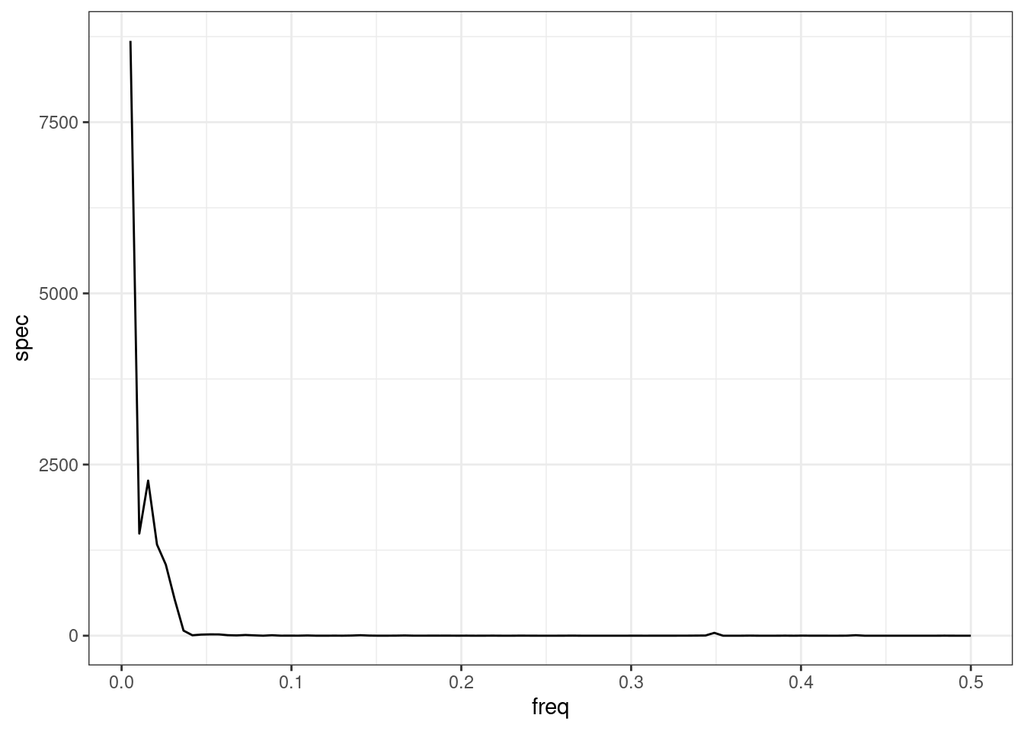

(a) Periodogram of raw data

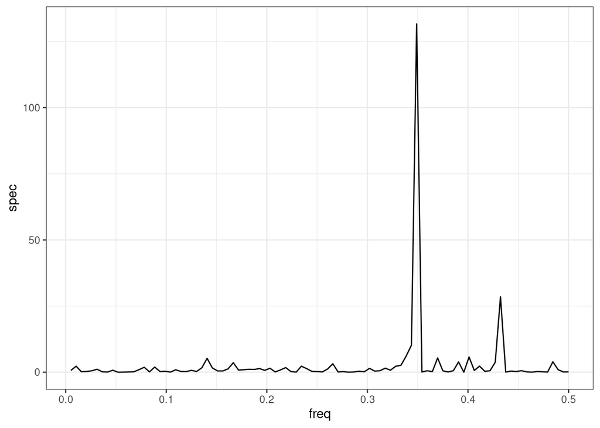

(b) Periodogram of differenced data

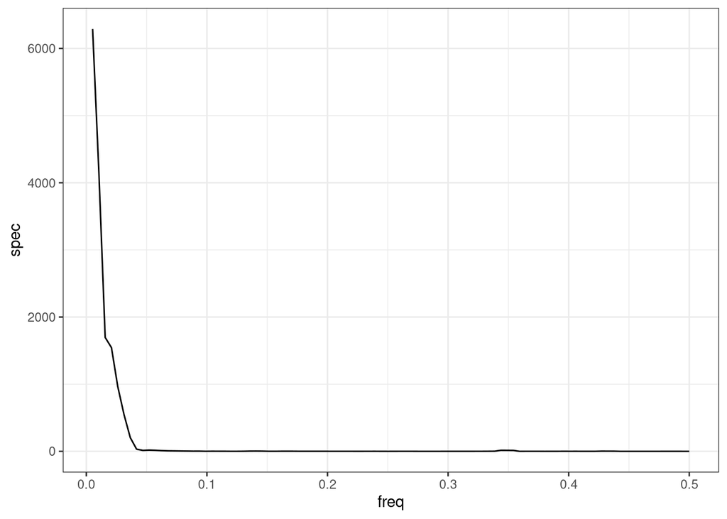

(c) Smoothed periodogram of raw data

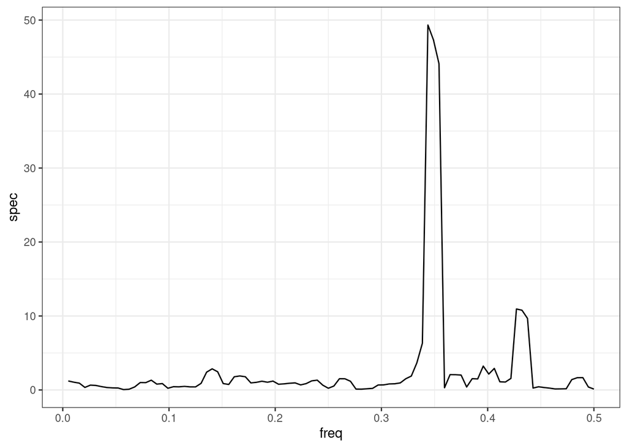

(d) Smoothed periodogram of differenced data

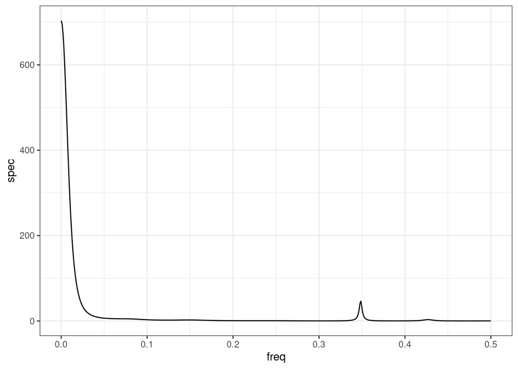

(e) AR spectral approximation of raw data

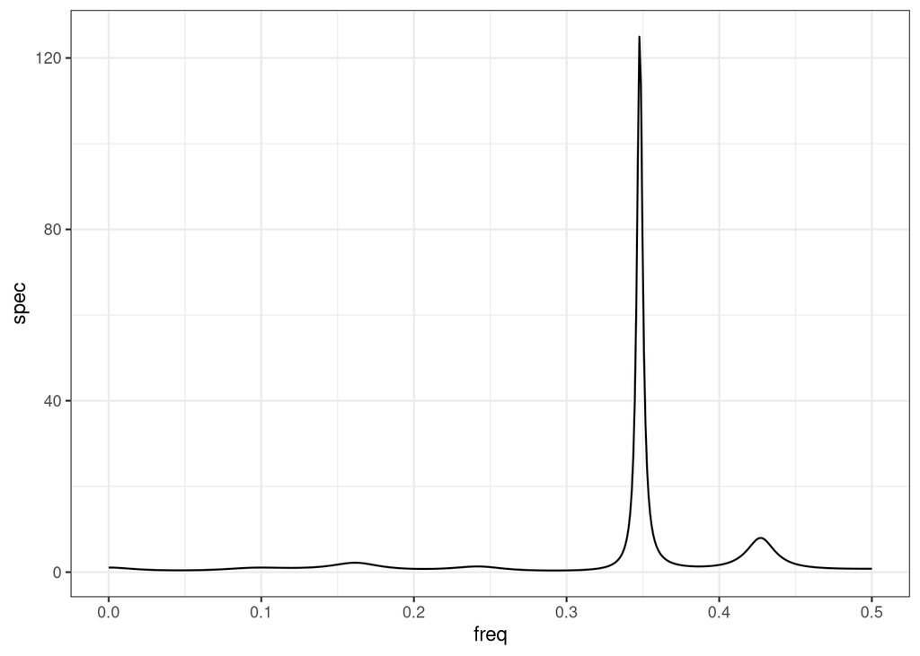

(f) AR spectral approximation of differenced data

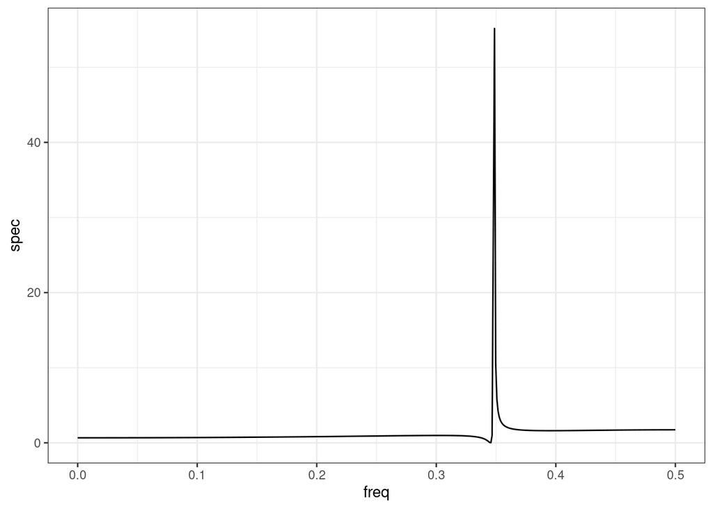

(g) ARMA spectrum of selected model

Figure 7: Spectral estimation plots

```r
plot_spectrum <- function(spec_list) {
  plt <- spec_list[1:2] |>
    tibble::as_tibble() |>
    ggplot2::ggplot(aes(x = freq, y = spec)) +
    ggplot2::geom_line()

  return(plt)
}

plot_spectrum(periodogram_raw)
plot_spectrum(periodogram_diff)
plot_spectrum(smoothed_periodogram_raw)
plot_spectrum(smoothed_periodogram_diff)
plot_spectrum(ar_spec_raw)
plot_spectrum(ar_spec_diff)
plot_spectrum(arma_spec)
```

- Note that the spectral approximations that use the raw data all capture the trend component and a small peak at a frequency of 0.348, whereas the approximations on the differenced series have a much stronger peak at 0.348, and capture a peak at 0.432, which was not captured previously.

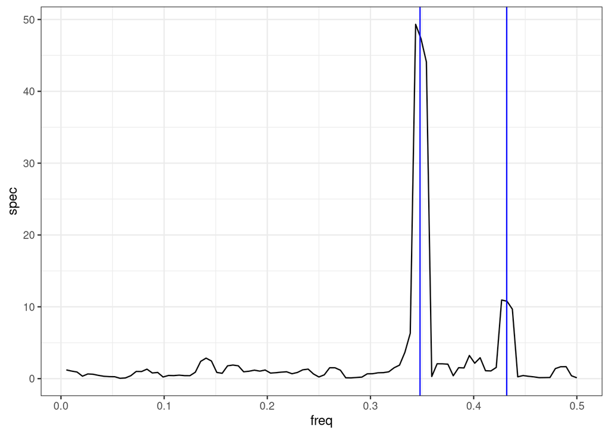

(a) Trading day peaks on smoothed periodogram

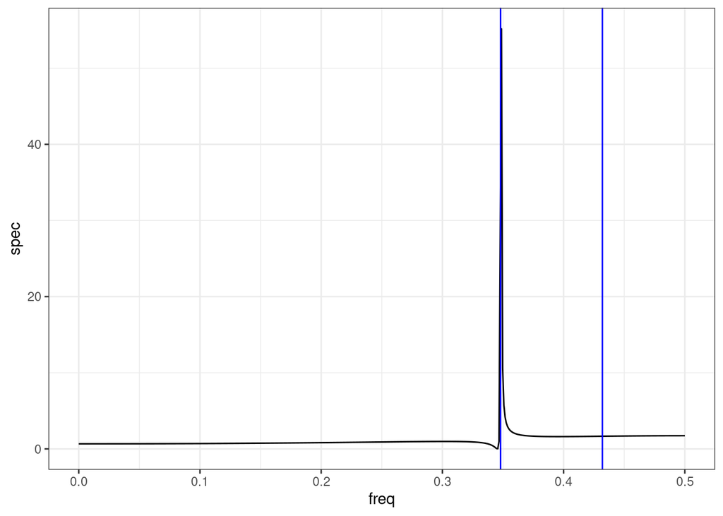

(b) Trading day peaks on ARMA spectrum

Figure 8: Trading day effects peaks

```r
plot_spectrum(smoothed_periodogram_diff) +
  ggplot2::geom_vline(xintercept = 0.348, colour = "blue") +
  ggplot2::geom_vline(xintercept = 0.432, colour = "blue")

plot_spectrum(arma_spec) +
  ggplot2::geom_vline(xintercept = 0.348, colour = "blue") +
  ggplot2::geom_vline(xintercept = 0.432, colour = "blue")
```

- As discussed in the TSM course, peaks at these frequencies are known to be suggestive of trading day effects. The presence of trading day effects in the series would explain many of the findings from the previous questions.
- Note that the ARMA spectrum for the fitted ARIMA (3,1,2) captures only one of these peaks. This suggests, that as we’d now expect, the fitted model isn’t capturing the trading day effects.

## Question (e) - Fitting a RegARIMA model

- As discovered in question (d), it is likely our data exhibits trading day effects.
- As described in the TSM lectures, in general we tend to observe lower trading activity on Mondays, Tuesdays and Wednesdays compared to the remaining days of the week. We make the assumption that the days within each of these two groups see roughly the same amount of activity.
- To construct a regressor, we use the approach discussed in the lectures. That is, we create six regressors, the first being the difference between the number of Mondays and Sundays in month $t$, the next being the difference between the the number of Tuesdays and Sundays in month $t$ and so on.
- We construct these regressors below.

```r
trading_day.df <- readr::read_csv("a1_trading_day_dates.csv") |>
  janitor::clean_names() |>
  tidyr::unite(month, c(year, month), sep = " ") |>
  dplyr::mutate(month = tsibble::yearmonth(month))
month_ <- trading_day.df$month
z1 <- trading_day.df$mon - trading_day.df$sun
z2 <- trading_day.df$tue - trading_day.df$sun
z3 <- trading_day.df$wed - trading_day.df$sun
z4 <- trading_day.df$thur - trading_day.df$sun
z5 <- trading_day.df$fri - trading_day.df$sun
z6 <- trading_day.df$sat - trading_day.df$sun

xregs.ts <- tibble::tibble(month_, z1, z2, z3, z4, z5, z6) |>
  dplyr::rename(month = month_) |>
  dplyr::slice(1:187) |>
  tsibble::as_tibble()

unknown_reg.ts <- dplyr::left_join(unknown.ts, xregs.ts, by = "month")
```

- Applying these regressors to the selected model, we run into some computational issues when calculating the coefficients.

  ```r
  unknown_reg.ts.fit <- unknown_reg.ts |>
    fabletools::model(
      fable::ARIMA(x ~ 0 + pdq(3,1,2) + PDQ(0,0,0) + z1 + z2 + z3 + z4 + z5 + z6)
    )
  unknown_reg.ts.fit |> fabletools::report()
  ```

  ```
  Series: x
  Model: LM w/ ARIMA(3,1,2) errors

  Coefficients:
           ar1      ar2     ar3     ma1      ma2       z1      z2      z3      z4
        1.3403  -0.9466  0.2989  0.0722  -0.3958  -0.2096  0.1984  0.3032  0.5012
  s.e.     NaN      NaN     NaN     NaN      NaN   0.0171  0.0154  0.0156  0.0167
            z5       z6
        0.4986  -0.6012
  s.e.  0.0152   0.0168

  sigma^2 estimated as 0.1216:  log likelihood=-63.56
  AIC=151.12   AICc=152.93   BIC=189.83
  ```

  ```r
  cat("\nCoefficient t-statistics:\n")
  ```

  ```
  Coefficient t-statistics:
  ```

  ```r
  unknown_reg.ts.fit[[1]][[1]]$fit$par$statistic
  ```

  ```
        ar1       ar2       ar3       ma1       ma2        z1        z2        z3
        NaN       NaN       NaN       NaN       NaN -12.27484  12.87012  19.45789
         z4        z5        z6
   30.07064  32.80433 -35.86695
  ```

- We can work around this by changing the fitting method from the default to maximum likelihood.

```r
unknown_reg.ts.fit <- unknown_reg.ts |>
  fabletools::model(
    fable::ARIMA(x ~ 0 + pdq(3,1,2) + PDQ(0,0,0) + z1 + z2 + z3 + z4 + z5 + z6,
                 method = "ML")
  )

unknown_reg.ts.fit |> fabletools::report()
```

```
Series: x
Model: LM w/ ARIMA(3,1,2) errors

Coefficients:
         ar1      ar2      ar3     ma1     ma2       z1      z2      z3      z4
      0.2722  -0.1091  -0.2902  1.1247  0.2584  -0.2053  0.1947  0.2987  0.5068
s.e.  0.6875   0.4882   0.3213  0.6980  0.5060   0.0173  0.0157  0.0162  0.0171
          z5       z6
      0.4998  -0.6048
s.e.  0.0154   0.0169

sigma^2 estimated as 0.1209:  log likelihood=-63.07
AIC=150.13   AICc=151.94   BIC=188.84
```

```r
cat("\nCoefficient t-statistics:\n")
```

```
Coefficient t-statistics:
```

```r
unknown_reg.ts.fit[[1]][[1]]$fit$par$statistic
```

```
        ar1         ar2         ar3         ma1         ma2          z1
  0.3959738  -0.2234505  -0.9032146   1.6114082   0.5106357 -11.8779836
         z2          z3          z4          z5          z6
 12.4152618  18.4607808  29.7165568  32.5241815 -35.7090055
```

- In any case, we see that this new model has a much lower AIC than the previous model, indicating it is a much better fit. However, while the regressor coefficients are all significant, we see that AR and MA components are no longer significant. This suggests, as we’d expect when including such important additional information, the previous model is no longer appropriate.
- As we did in question (b), we search through the space of relevant RegARIMA models to select a new model.

```r
models <- base::expand.grid(p = 0:5, q = 0:5)

results_reg <- tibble::tibble()

for (i in 1:nrow(models)) {
  p <- models[i, "p"]
  q <- models[i, "q"]

  try({
    model_results <-
      unknown_reg.ts |>
      fabletools::model(
        fable::ARIMA(x ~ 0 + pdq(p, 1, q) + PDQ(0, 0, 0) +
                         z1 + z2 + z3 + z4 + z5 + z6)
      ) |>
      fabletools::glance()
  })
  if (nrow(model_results) > 0) { # Only include non-empty results
    model_results <-
      model_results |>
      dplyr::mutate(model = "ARIMA", p = p, d = 1, q = q, .before = sigma2) |>
      dplyr::mutate(dplyr::across(where(is.numeric), round, 3)) |>
      dplyr::select(-.model, -ar_roots, -ma_roots)

    results_reg <- dplyr::bind_rows(results_reg, model_results)
  }
}

results_reg <- results_reg |> dplyr::arrange(AIC, p, q)

knitr::kable(head(results_reg, 13))
```

Table 2: RegARIMA model outputs

| model | p | d | q | sigma2 | log_lik | AIC | AICc | BIC |
| --- | --- | --- | --- | --- | --- | --- | --- | --- |
| ARIMA | 2 | 1 | 1 | 0.120 | -63.562 | 147.124 | 148.382 | 179.382 |
| ARIMA | 4 | 1 | 3 | 0.116 | -60.035 | 148.070 | 150.526 | 193.230 |
| ARIMA | 3 | 1 | 1 | 0.120 | -63.176 | 148.351 | 149.869 | 183.835 |
| ARIMA | 2 | 1 | 2 | 0.121 | -63.291 | 148.582 | 150.099 | 184.065 |
| ARIMA | 5 | 1 | 3 | 0.116 | -59.765 | 149.529 | 152.353 | 197.916 |
| ARIMA | 4 | 1 | 4 | 0.116 | -59.799 | 149.599 | 152.422 | 197.985 |
| ARIMA | 2 | 1 | 3 | 0.121 | -62.835 | 149.670 | 151.473 | 188.379 |
| ARIMA | 4 | 1 | 1 | 0.121 | -62.997 | 149.993 | 151.797 | 188.702 |
| ARIMA | 4 | 1 | 2 | 0.121 | -62.415 | 150.830 | 152.946 | 192.765 |
| ARIMA | 3 | 1 | 2 | 0.122 | -63.562 | 151.124 | 152.928 | 189.833 |
| ARIMA | 3 | 1 | 3 | 0.121 | -62.576 | 151.152 | 153.269 | 193.087 |
| ARIMA | 2 | 1 | 4 | 0.121 | -62.623 | 151.246 | 153.363 | 193.181 |
| ARIMA | 4 | 1 | 5 | 0.117 | -59.736 | 151.473 | 154.691 | 203.084 |

- We select the $(2,1,1)$ model, it has the lowest AIC and fewer parameters than any of the other models with similar AICs.

  ```r
  unknown_reg_final.ts.fit <- unknown_reg.ts |>
    fabletools::model(
      fable::ARIMA(x ~ 0 + pdq(2,1,1) + PDQ(0,0,0) + z1 + z2 + z3 + z4 + z5 + z6)
    )

  unknown_reg_final.ts.fit |> fabletools::report()
  ```

  ```
  Series: x
  Model: LM w/ ARIMA(2,1,1) errors

  Coefficients:
           ar1      ar2     ma1       z1      z2      z3      z4      z5       z6
        0.7464  -0.5035  0.6661  -0.2096  0.1984  0.3032  0.5012  0.4986  -0.6012
  s.e.  0.0786   0.0754  0.0800   0.0171  0.0154  0.0156  0.0167  0.0152   0.0168

  sigma^2 estimated as 0.1202:  log likelihood=-63.56
  AIC=147.12   AICc=148.38   BIC=179.38
  ```

  ```r
  cat("\nCoefficient t-statistics:\n")
  ```

  ```
  Coefficient t-statistics:
  ```

  ```r
  unknown_reg_final.ts.fit[[1]][[1]]$fit$par$statistic
  ```

  ```
         ar1        ar2        ma1         z1         z2         z3         z4
    9.492734  -6.678459   8.325397 -12.275392  12.870445  19.458289  30.069912
          z5         z6
   32.803670 -35.865746
  ```

## Question (f) - Deriving forecast equations

- See image attached to submission.

## Question (g) - Calculating forecasts

- We calculate forecasts and their associated 95% confidence intervals below.

```r
trading_day_forecast.df <- trading_day.df[188:189,]

z1_f <- trading_day_forecast.df$mon - trading_day_forecast.df$sun
z2_f <- trading_day_forecast.df$tue - trading_day_forecast.df$sun
z3_f <- trading_day_forecast.df$wed - trading_day_forecast.df$sun
z4_f <- trading_day_forecast.df$thur - trading_day_forecast.df$sun
z5_f <- trading_day_forecast.df$fri - trading_day_forecast.df$sun
z6_f <- trading_day_forecast.df$sat - trading_day_forecast.df$sun

xreg <- base::cbind(z1, z2, z3, z4, z5, z6)[1:187,]
xreg_new <- base::cbind(z1_f, z2_f, z3_f, z4_f, z5_f, z6_f)

stats.fit <- stats::arima(unknown_reg.ts$x, order = c(2,1,1), xreg = xreg)
stats.predict <- stats::predict(stats.fit, n.ahead = 2, newxreg = xreg_new)

forecast_point <- stats.predict$pred[1:2]
forecast_se <- stats.predict$se[1:2]
forecast_interval_upper <- forecast_point + 1.96 * forecast_se
forecast_interval_lower <- forecast_point - 1.96 * forecast_se
```

- For August 2018, we get a point estimate of 37.334, with an associated 95% forecast interval of [36.671, 37.997].
- For September 2018, we get a point estimate of 34.35, with an associated 95% forecast interval of [32.619, 36.082].
- The forecast is plotted in Figure 9 below.

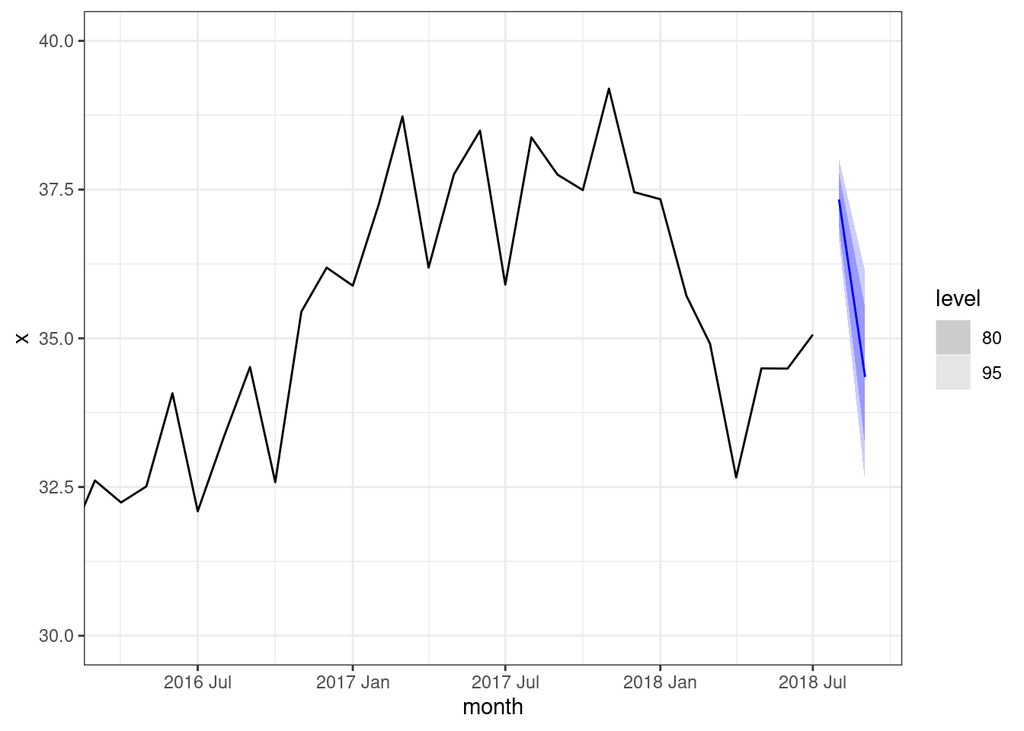

Figure 9: Two month ahead forecast

```r
unknown_reg_future <-
  tsibble::new_data(unknown_reg.ts, n = 2) |>
  dplyr::mutate(
    z1 = z1_f, z2 = z2_f, z3 = z3_f, z4 = z4_f, z5 = z5_f, z6 = z6_f
  )

first_period <- trading_day.df[[160, "month"]]
last_period <- trading_day.df[[nrow(trading_day.df), "month"]]

unknown_reg_final.ts.fit |>
  fabletools::forecast(new_data = unknown_reg_future) |>
  ggplot2::autoplot(unknown_reg.ts) +
  ggplot2::coord_cartesian(
    xlim = c(first_period, last_period),
    ylim = c(30, 40)
  )
```